# weatherproject1

Project | Weather Summary Classification

### Problem:

Develop a robust machine learning model to accurately classify weather summaries based on various meteorological factors. By utilizing this model, the company aims to improve weather forecasting accuracy, provide better insights to customers, and optimize weather-dependent operations.

### Workflow:

- **Explore the Dataset**: Uncover patterns, distributions, and relationships within the data.
- **Conduct Extensive Exploratory Data Analysis (EDA)**: Dive deep into bivariate relationships against the target.
- **Preprocessing Steps**:
  - Remove irrelevant features
  - Address missing values
  - Treat outliers
  - Encode categorical variables
- **Model Building & Evaluation**:
  - Implement and tune classification models including Logistic Regression, Random Forest, XGBoost.

## Import Libraries

```python
import pandas as pd
import numpy as np
import matplotlib.pyplot as plt
import seaborn as sns
from sklearn.preprocessing import LabelEncoder, StandardScaler
from sklearn.model_selection import train_test_split
from sklearn.model_selection import GridSearchCV
from sklearn.linear_model import LogisticRegression
from sklearn.ensemble import RandomForestClassifier
from xgboost import XGBClassifier
from sklearn.metrics import (accuracy_score,precision_score,recall_score,f1_score,classification_report,confusion_matrix,precision_recall_curve,auc)
from sklearn.metrics import roc_curve, auc
import warnings
warnings.filterwarnings('ignore')
```

## Fetching data

```python
data = pd.read_csv("weatherHistory.csv")
data.head(3)
```

|  | Formatted Date | Summary | Precip Type | Temperature (C) | Apparent Temperature (C) | Humidity | Wind Speed (km/h) | Wind Bearing (degrees) | Visibility (km) | Pressure (millibars) | Daily Summary |
| --- | --- | --- | --- | --- | --- | --- | --- | --- | --- | --- | --- |
| 0 | 2006-04-01 00:00:00.000 +0200 | Partly Cloudy | rain | 9.472222 | 7.388889 | 0.89 | 14.1197 | 251 | 15.8263 | 1015.13 | Partly cloudy throughout the day. |
| 1 | 2006-04-01 01:00:00.000 +0200 | Partly Cloudy | rain | 9.355556 | 7.227778 | 0.86 | 14.2646 | 259 | 15.8263 | 1015.63 | Partly cloudy throughout the day. |
| 2 | 2006-04-01 02:00:00.000 +0200 | Mostly Cloudy | rain | 9.377778 | 9.377778 | 0.89 | 3.9284 | 204 | 14.9569 | 1015.94 | Partly cloudy throughout the day. |

## Datatset Overview

```python
data.shape
```

```
(96453, 11)
```

| Variable | Description |
| --- | --- |
| Formatted Date | Timestamp of the weather observation (to be converted to datetime format) |
| Summary | Short description of weather conditions (e.g., Partly Cloudy, Rain) |
| Precip Type | Type of precipitation observed (e.g., rain, snow); some values may be missing |
| Temperature (C) | Measured air temperature in degrees Celsius |
| Apparent Temperature (C) | “Feels like” temperature considering wind and humidity |
| Humidity | Relative humidity (range: 0 to 1) |
| Wind Speed (km/h) | Speed of wind in kilometers per hour |
| Wind Bearing (degrees) | Direction of wind measured in degrees (0°–360°) |
| Visibility (km) | Visibility distance in kilometers |
| Pressure (millibars) | Atmospheric pressure in millibars |
| Daily Summary | Detailed summary of weather for the day |

```python
data.info()
```

```
<class 'pandas.core.frame.DataFrame'>
RangeIndex: 96453 entries, 0 to 96452
Data columns (total 11 columns):
 #   Column                    Non-Null Count  Dtype
---  ------                    --------------  -----
 0   Formatted Date            96453 non-null  object
 1   Summary                   96453 non-null  object
 2   Precip Type               95936 non-null  object
 3   Temperature (C)           96453 non-null  float64
 4   Apparent Temperature (C)  96453 non-null  float64
 5   Humidity                  96453 non-null  float64
 6   Wind Speed (km/h)         96453 non-null  float64
 7   Wind Bearing (degrees)    96453 non-null  int64
 8   Visibility (km)           96453 non-null  float64
 9   Pressure (millibars)      96453 non-null  float64
 10  Daily Summary             96453 non-null  object
dtypes: float64(6), int64(1), object(4)
memory usage: 8.1+ MB
```

```python
data.describe()
```

|  | Temperature (C) | Apparent Temperature (C) | Humidity | Wind Speed (km/h) | Wind Bearing (degrees) | Visibility (km) | Pressure (millibars) |
| --- | --- | --- | --- | --- | --- | --- | --- |
| count | 96453.000000 | 96453.000000 | 96453.000000 | 96453.000000 | 96453.000000 | 96453.000000 | 96453.000000 |
| mean | 11.932678 | 10.855029 | 0.734899 | 10.810640 | 187.509232 | 10.347325 | 1003.235956 |
| std | 9.551546 | 10.696847 | 0.195473 | 6.913571 | 107.383428 | 4.192123 | 116.969906 |
| min | -21.822222 | -27.716667 | 0.000000 | 0.000000 | 0.000000 | 0.000000 | 0.000000 |
| 25% | 4.688889 | 2.311111 | 0.600000 | 5.828200 | 116.000000 | 8.339800 | 1011.900000 |
| 50% | 12.000000 | 12.000000 | 0.780000 | 9.965900 | 180.000000 | 10.046400 | 1016.450000 |
| 75% | 18.838889 | 18.838889 | 0.890000 | 14.135800 | 290.000000 | 14.812000 | 1021.090000 |
| max | 39.905556 | 39.344444 | 1.000000 | 63.852600 | 359.000000 | 16.100000 | 1046.380000 |

#### Renaming columns names

```python
data = data.rename(columns={
    'Formatted Date': 'formatted_date',
    'Summary': 'summary',
    'Precip Type': 'precip_type',
    'Temperature (C)': 'temperature',
    'Apparent Temperature (C)': 'apparent_temperature',
    'Humidity': 'humidity',
    'Wind Speed (km/h)': 'wind_speed',
    'Wind Bearing (degrees)': 'wind_bearing',
    'Visibility (km)': 'visibility',
    'Pressure (millibars)': 'pressure',
    'Daily Summary': 'daily_summary'
})
```

```python
data.columns
```

```
Index(['formatted_date', 'summary', 'precip_type', 'temperature',
       'apparent_temperature', 'humidity', 'wind_speed', 'wind_bearing',
       'visibility', 'pressure', 'daily_summary'],
      dtype='object')
```

```python
# Checking Target Variable
print(data["summary"].value_counts())
```

```
summary
Partly Cloudy                          31733
Mostly Cloudy                          28094
Overcast                               16597
Clear                                  10890
Foggy                                   7148
Breezy and Overcast                      528
Breezy and Mostly Cloudy                 516
Breezy and Partly Cloudy                 386
Dry and Partly Cloudy                     86
Windy and Partly Cloudy                   67
Light Rain                                63
Breezy                                    54
Windy and Overcast                        45
Humid and Mostly Cloudy                   40
Drizzle                                   39
Breezy and Foggy                          35
Windy and Mostly Cloudy                   35
Dry                                       34
Humid and Partly Cloudy                   17
Dry and Mostly Cloudy                     14
Rain                                      10
Windy                                      8
Humid and Overcast                         7
Windy and Foggy                            4
Windy and Dry                              1
Dangerously Windy and Partly Cloudy        1
Breezy and Dry                             1
Name: count, dtype: int64
```

```python
# Reduced Data (Using only 5 classes)
data = data[(data["summary"] == "Overcast") | (data["summary"] == "Clear") | (data["summary"] == "Foggy")   | (data["summary"] == "Partly Cloudy") | (data["summary"] == "Mostly Cloudy") ]
data.info()
```

```
<class 'pandas.core.frame.DataFrame'>
Index: 94462 entries, 0 to 96452
Data columns (total 11 columns):
 #   Column                Non-Null Count  Dtype
---  ------                --------------  -----
 0   formatted_date        94462 non-null  object
 1   summary               94462 non-null  object
 2   precip_type           93945 non-null  object
 3   temperature           94462 non-null  float64
 4   apparent_temperature  94462 non-null  float64
 5   humidity              94462 non-null  float64
 6   wind_speed            94462 non-null  float64
 7   wind_bearing          94462 non-null  int64
 8   visibility            94462 non-null  float64
 9   pressure              94462 non-null  float64
 10  daily_summary         94462 non-null  object
dtypes: float64(6), int64(1), object(4)
memory usage: 8.6+ MB
```

```python
print(data["summary"].value_counts())
```

```
summary
Partly Cloudy    31733
Mostly Cloudy    28094
Overcast         16597
Clear            10890
Foggy             7148
Name: count, dtype: int64
```

### Removing Null & Duplicates

```python
# Calculating Missing Values
data.isnull().sum()
```

```
formatted_date            0
summary                   0
precip_type             517
temperature               0
apparent_temperature      0
humidity                  0
wind_speed                0
wind_bearing              0
visibility                0
pressure                  0
daily_summary             0
dtype: int64
```

```python
data.dropna(inplace=True)
# Again checking for values
data.isnull().sum().sum()
```

```
0
```

```python
# Calculating number of duplicated values
print("Duplicated Values: ",data.duplicated().sum())
```

```
Duplicated Values:  24
```

```python
# Removing duplicated values
data.drop_duplicates(inplace=True)
# Again checking for duplicated values
print("Duplicated Values: ", data.duplicated().sum())
```

```
Duplicated Values:  0
```

### Rounding up 2 decimals for fload64

```python
# Rounding up the float64 data upto 2 decimals.
float_cols = data.select_dtypes(include='float')
data[float_cols.columns] = float_cols.round(2)
data.head(3)
```

|  | formatted_date | summary | precip_type | temperature | apparent_temperature | humidity | wind_speed | wind_bearing | visibility | pressure | daily_summary |
| --- | --- | --- | --- | --- | --- | --- | --- | --- | --- | --- | --- |
| 0 | 2006-04-01 00:00:00.000 +0200 | Partly Cloudy | rain | 9.47 | 7.39 | 0.89 | 14.12 | 251 | 15.83 | 1015.13 | Partly cloudy throughout the day. |
| 1 | 2006-04-01 01:00:00.000 +0200 | Partly Cloudy | rain | 9.36 | 7.23 | 0.86 | 14.26 | 259 | 15.83 | 1015.63 | Partly cloudy throughout the day. |
| 2 | 2006-04-01 02:00:00.000 +0200 | Mostly Cloudy | rain | 9.38 | 9.38 | 0.89 | 3.93 | 204 | 14.96 | 1015.94 | Partly cloudy throughout the day. |

```python
data2=data.copy()
```

```python
# Convert the 'Formatted Date' column to datetime
data2['formatted_date'] = pd.to_datetime(data2['formatted_date'])
```

```python
data2.set_index('formatted_date', inplace=True)
```

```python
data2.head(3)
```

| formatted_date | summary | precip_type | temperature | apparent_temperature | humidity | wind_speed | wind_bearing | visibility | pressure | daily_summary |
| --- | --- | --- | --- | --- | --- | --- | --- | --- | --- | --- |
| 2006-04-01 00:00:00+02:00 | Partly Cloudy | rain | 9.47 | 7.39 | 0.89 | 14.12 | 251 | 15.83 | 1015.13 | Partly cloudy throughout the day. |
| 2006-04-01 01:00:00+02:00 | Partly Cloudy | rain | 9.36 | 7.23 | 0.86 | 14.26 | 259 | 15.83 | 1015.63 | Partly cloudy throughout the day. |
| 2006-04-01 02:00:00+02:00 | Mostly Cloudy | rain | 9.38 | 9.38 | 0.89 | 3.93 | 204 | 14.96 | 1015.94 | Partly cloudy throughout the day. |

#### Droping Irrelevant Columns

```python
data.drop(columns=["daily_summary", "formatted_date","apparent_temperature"], axis=1, inplace=True)
data.head(3)
```

|  | summary | precip_type | temperature | humidity | wind_speed | wind_bearing | visibility | pressure |
| --- | --- | --- | --- | --- | --- | --- | --- | --- |
| 0 | Partly Cloudy | rain | 9.47 | 0.89 | 14.12 | 251 | 15.83 | 1015.13 |
| 1 | Partly Cloudy | rain | 9.36 | 0.86 | 14.26 | 259 | 15.83 | 1015.63 |
| 2 | Mostly Cloudy | rain | 9.38 | 0.89 | 3.93 | 204 | 14.96 | 1015.94 |

## EDA

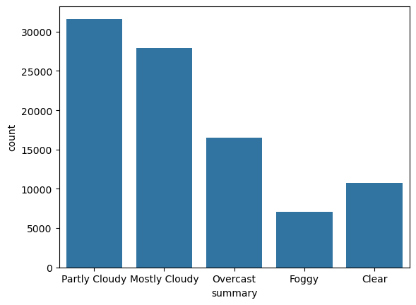

```python
sns.countplot(data=data, x='summary')
plt.show()
```

- **Partly Cloudy** and **Mostly Cloudy** conditions are the most frequently occurring weather types, significantly dominating the dataset.
- **Foggy** and **Clear** conditions are comparatively rare, suggesting limited visibility and completely clear skies are less common in this dataset.

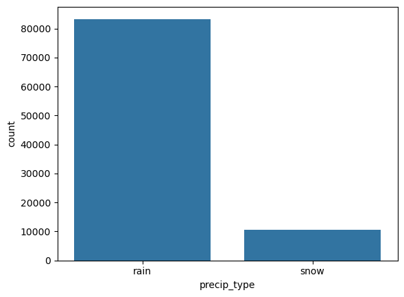

```python
sns.countplot(data=data, x='precip_type')
plt.show()
```

- **Rain** is the dominant form of precipitation in the dataset, occurring far more frequently than **snow**.

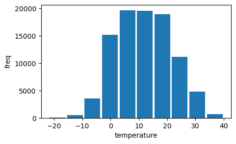

```python
fig,ax=plt.subplots(figsize=(5,3))
plt.hist(data["temperature"],bins=10,rwidth=0.9)
plt.xlabel("temperature")
plt.ylabel("freq")
```

- Most temperatures in the dataset range between 0°C and 20°C, indicating a moderate climate.
- Extremely low (below -10°C) and high (above 30°C) temperatures are rare, suggesting limited occurrence of extreme weather.

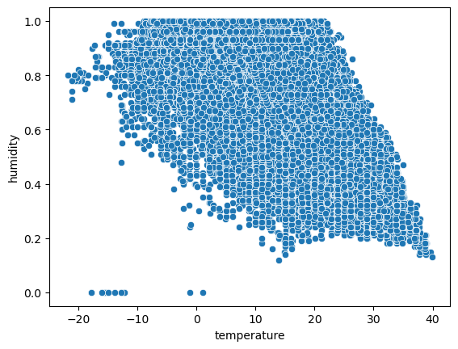

```python
sns.scatterplot(x='temperature',y='humidity',data=data)
plt.show()
```

- Humidity tends to decrease as temperature increases, indicating a negative correlation between the two variables.
- High humidity values (above 0.8) are mostly observed at lower temperatures, while higher temperatures are associated with lower humidity.

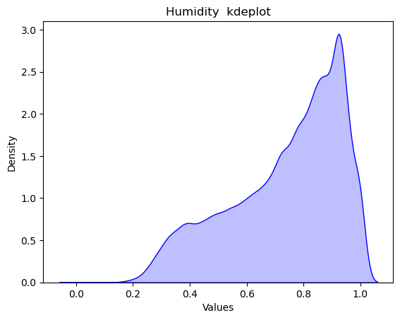

```python
sns.kdeplot(data['humidity'], color='blue', fill=True)
plt.xlabel('Values')
plt.ylabel('Density')
plt.title('Humidity  kdeplot')
plt.show()
```

- The KDE plot shows that humidity values are heavily concentrated between 0.7 and 1.0, indicating high humidity is common in the dataset.
- There are fewer instances of low humidity, with values below 0.3 occurring rarely.

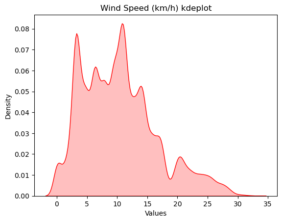

```python
sns.kdeplot(data['wind_speed'], color='red', fill=True)
plt.xlabel('Values')
plt.ylabel('Density')
plt.title('Wind Speed (km/h) kdeplot')
plt.show()
```

- The KDE plot reveals that wind speeds are most frequently observed between 5 km/h and 15 km/h.
- Extremely low and very high wind speeds are relatively rare in the dataset.

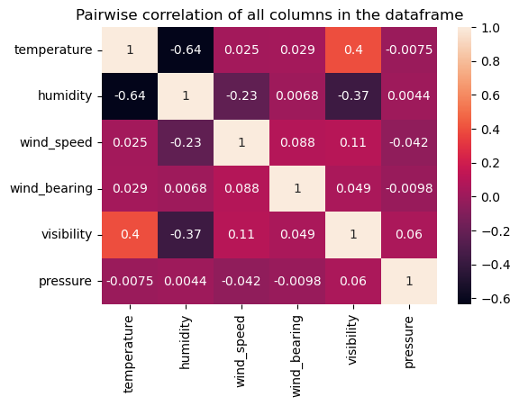

```python
plt.figure(figsize=(6,4))
sns.heatmap(data.select_dtypes(include='number').corr(), annot=True)
plt.title("Pairwise correlation of all columns in the dataframe")
```

- Temperature and humidity exhibit a strong negative correlation (-0.64), indicating that higher temperatures tend to coincide with lower humidity levels.
- Visibility shows a moderate positive correlation with temperature (0.4) and a negative correlation with humidity (-0.37), suggesting clearer conditions in warmer, less humid environments.
- Other variables such as pressure, wind speed, and wind bearing show weak or negligible correlations with the rest of the features.

## Data Pre Processing

```python
# Checking whether the target variable is balanced or unbalanced
counts = data["summary"].value_counts()
total = counts.sum()
percentages = (counts / total) * 100
print(percentages)
```

```
summary
Partly Cloudy    33.675110
Mostly Cloudy    29.720723
Overcast         17.584992
Clear            11.441531
Foggy             7.577645
Name: count, dtype: float64
```

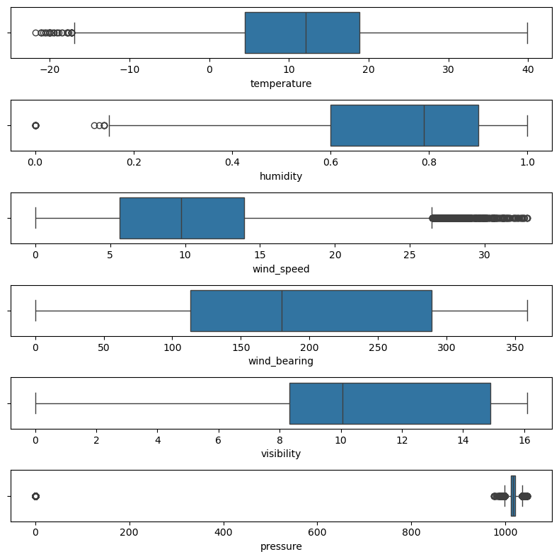

```python
cols =['temperature','humidity', 'wind_speed','wind_bearing','visibility','pressure']
figure,axis = plt.subplots(6,1,figsize=(8,8))
c=0
for i in range(6):
    sns.boxplot(data,x=cols[c],ax=axis[c])
    c+=1
plt.tight_layout()
plt.show()
```

```python
# Define continuous features
continuous_features = ['temperature','humidity', 'wind_speed','wind_bearing','visibility','pressure']
# Compute Q1, Q3, and IQR
Q1 = data[continuous_features].quantile(0.25)
Q3 = data[continuous_features].quantile(0.75)
IQR = Q3 - Q1

# Count outliers per column
outliers_count_specified = ((data[continuous_features] < (Q1 - 1.5 * IQR)) |
                            (data[continuous_features] > (Q3 + 1.5 * IQR))).sum()

# Display number of outliers per continuous column
print("Outlier count per continuous feature:")
print(outliers_count_specified)

# Create a mask for rows without any outliers
non_outlier_mask = ~((data[continuous_features] < (Q1 - 1.5 * IQR)) |
                     (data[continuous_features] > (Q3 + 1.5 * IQR))).any(axis=1)

# Apply the mask to remove outliers
data = data[non_outlier_mask].reset_index(drop=True)

# Confirm the shape or view the cleaned data
print("Data shape after removing outliers:", data.shape)
```

```
Outlier count per continuous feature:
temperature       36
humidity          28
wind_speed      1394
wind_bearing       0
visibility         0
pressure        4263
dtype: int64
Data shape after removing outliers: (88347, 8)
```

### Label Encoding

```python
# Separate encoders for each column
le_summary = LabelEncoder()
le_precip = LabelEncoder()
# Apply label encoding
data['summary'] = le_summary.fit_transform(data['summary'])
data['precip_type'] = le_precip.fit_transform(data['precip_type'])
```

```python
# Print encoded class mappings for 'Summary'
print("Encoded classes for 'Summary':")
for i, label in enumerate(le_summary.classes_):
    print(f"{i} → {label}")

print("\nEncoded classes for 'Precip Type':")
for i, label in enumerate(le_precip.classes_):
    print(f"{i} → {label}")
```

```
Encoded classes for 'Summary':
0 → Clear
1 → Foggy
2 → Mostly Cloudy
3 → Overcast
4 → Partly Cloudy

Encoded classes for 'Precip Type':
0 → rain
1 → snow
```

## Spliting data into X, y & Resampling Data

```python
X = data.drop(columns="summary", axis=1)
```

```python
y = data["summary"]
```

#### Random Over sampling

```python
from imblearn.over_sampling import RandomOverSampler
from collections import Counter
# Check original class distribution
print("Original class distribution:", Counter(y))
# Apply random oversampling
oversampler = RandomOverSampler(random_state=42)
X_resampled, y_resampled = oversampler.fit_resample(X, y)
# Check the new class distribution
print("Resampled class distribution:", Counter(y_resampled))
```

```
Original class distribution: Counter({4: 30720, 2: 26674, 3: 15006, 0: 9638, 1: 6309})
Resampled class distribution: Counter({4: 30720, 2: 30720, 3: 30720, 1: 30720, 0: 30720})
```

#### Train Test Split

```python
X_train, X_test, y_train, y_test = train_test_split(X_resampled, y_resampled, test_size=0.20, random_state=42)
```

```python
print("X_train shape:", X_train.shape)
print("y_train shape:", y_train.shape)
print("X_test shape:", X_test.shape)
print("y_test shape:", y_test.shape)
```

```
X_train shape: (122880, 7)
y_train shape: (122880,)
X_test shape: (30720, 7)
y_test shape: (30720,)
```

#### Standard scaling

```python
# Apply scaling on the input_df DataFrame
scaler = StandardScaler()
X_train = scaler.fit_transform(X_train)
X_test = scaler.transform(X_test)
```

## Logistic Regression

```python
# Define parameter grid for Logistic Regression
param_grid_lr = {
    'C': [0.01, 0.1, 1, 10],
    'penalty': ['l2'],  # 'l1' can be used with solver='liblinear' or 'saga'
    'solver': ['lbfgs'],  # Suitable for l2 penalty
    'max_iter': [100, 200, 300]
}
# Initialize the model
lr = LogisticRegression(random_state=42)

# GridSearchCV
grid_search_lr = GridSearchCV(estimator=lr, param_grid=param_grid_lr,
                              cv=3, n_jobs=-1, verbose=1, scoring='f1_macro')
# Fit
grid_search_lr.fit(X_train, y_train)
# Best model
best_lr = grid_search_lr.best_estimator_
print("Best Parameters (LogReg):", grid_search_lr.best_params_)

# Evaluation
y_pred = best_lr.predict(X_test)
print("LogReg Accuracy:", accuracy_score(y_test, y_pred_lr))
print("LogReg Precision:", precision_score(y_test, y_pred_lr, average='macro'))
print("LogReg Recall:", recall_score(y_test, y_pred_lr, average='macro'))
print("LogReg F1 Score:", f1_score(y_test, y_pred_lr, average='macro'))
```

[output not shown]

```python
# Generate classification report
report = classification_report(y_test, y_pred)
print("Classification Report:",report)
```

```
Classification Report:               precision    recall  f1-score   support

           0       0.44      0.52      0.47      6262
           1       0.97      1.00      0.98      6113
           2       0.37      0.22      0.27      6161
           3       0.49      0.61      0.54      6102
           4       0.44      0.41      0.43      6082

    accuracy                           0.55     30720
   macro avg       0.54      0.55      0.54     30720
weighted avg       0.54      0.55      0.54     30720
```

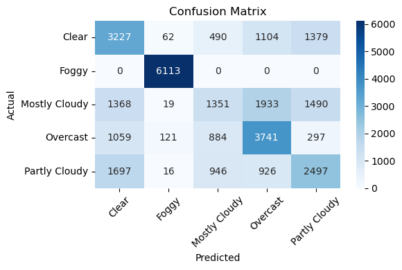

```python
# Compute confusion matrix
cm = confusion_matrix(y_test, y_pred)
# Plot confusion matrix with class labels
plt.figure(figsize=(6, 4))
sns.heatmap(cm, annot=True, fmt='d', cmap='Blues',
            xticklabels=le_summary.classes_,
            yticklabels=le_summary.classes_)
plt.xlabel('Predicted')
plt.ylabel('Actual')
plt.title('Confusion Matrix')
plt.xticks(rotation=45)
plt.yticks(rotation=0)
plt.tight_layout()
plt.show()
```

## XGBoost Classifier

```python
# Define parameter grid for hyperparameter tuning
param_grid = {
    'n_estimators': [100, 200],
    'max_depth': [3, 5, 7],
    'learning_rate': [0.05, 0.1, 0.2],
    'subsample': [0.8, 1.0],
    'colsample_bytree': [0.8, 1.0]
}
# Initialize XGBoost Classifier
xgb = XGBClassifier(use_label_encoder=False, eval_metric='mlogloss', random_state=42)

# Setup GridSearchCV
grid_search = GridSearchCV(estimator=xgb, param_grid=param_grid,
                           scoring='f1_macro', cv=3, n_jobs=-1, verbose=1)
# Fit the model
grid_search.fit(X_train, y_train)

# Best estimator from grid search
best_xgb = grid_search.best_estimator_

# Predict on the test set
y_pred = best_xgb.predict(X_test)

# Evaluate the tuned model
print("Tuned XGBoost Evaluation Metrics:")
print(f"Accuracy : {accuracy_score(y_test, y_pred):.4f}")
print(f"Precision: {precision_score(y_test, y_pred, average='macro'):.4f}")
print(f"Recall   : {recall_score(y_test, y_pred, average='macro'):.4f}")
print(f"F1 Score : {f1_score(y_test, y_pred, average='macro'):.4f}")
```

```
Fitting 3 folds for each of 72 candidates, totalling 216 fits
Tuned XGBoost Evaluation Metrics:
Accuracy : 0.7088
Precision: 0.7009
Recall   : 0.7084
F1 Score : 0.7014
```

```python
# Generate classification report
report = classification_report(y_test, y_pred)
print("Classification Report:",report)
```

```
Classification Report:               precision    recall  f1-score   support

           0       0.68      0.82      0.75      6262
           1       1.00      1.00      1.00      6113
           2       0.53      0.46      0.49      6161
           3       0.71      0.78      0.74      6102
           4       0.58      0.48      0.53      6082

    accuracy                           0.71     30720
   macro avg       0.70      0.71      0.70     30720
weighted avg       0.70      0.71      0.70     30720
```

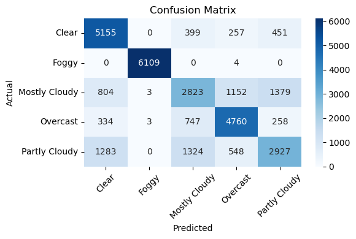

```python
# Compute confusion matrix
cm = confusion_matrix(y_test, y_pred)
# Plot confusion matrix with class labels
plt.figure(figsize=(6, 4))
sns.heatmap(cm, annot=True, fmt='d', cmap='Blues',
            xticklabels=le_summary.classes_,
            yticklabels=le_summary.classes_)
plt.xlabel('Predicted')
plt.ylabel('Actual')
plt.title('Confusion Matrix')
plt.xticks(rotation=45)
plt.yticks(rotation=0)
plt.tight_layout()
plt.show()
```

## Random Forest Classifier

```python
# Extended parameter grid
param_grid = {
    'n_estimators': [200,300],               # Number of trees
    'max_depth': [None, 10,],          # Maximum depth of each tree
    'min_samples_split': [2,3 ],          # Min samples required to split a node
    'min_samples_leaf': [1, 2],            # Min samples required at each leaf
    'max_features': ['auto', 'sqrt'], # Number of features to consider at each split

}
# Initialize the classifier
rf = RandomForestClassifier(random_state=42)

# Setup GridSearchCV
grid_search = GridSearchCV(estimator=rf,
                           param_grid=param_grid,
                           cv=3,
                           n_jobs=-1,
                           verbose=1,
                           scoring='f1_macro')
# Fit the grid search
grid_search.fit(X_train, y_train)

# Best model
best_rf = grid_search.best_estimator_
print("Best Parameters:", grid_search.best_params_)

# Evaluate the model
y_pred = best_rf.predict(X_test)
print(f"Accuracy : {accuracy_score(y_test, y_pred):.4f}")
print(f"Precision: {precision_score(y_test, y_pred, average='macro'):.4f}")
print(f"Recall   : {recall_score(y_test, y_pred, average='macro'):.4f}")
print(f"F1 Score : {f1_score(y_test, y_pred, average='macro'):.4f}")
```

```
Fitting 3 folds for each of 32 candidates, totalling 96 fits
Best Parameters: {'max_depth': None, 'max_features': 'sqrt', 'min_samples_leaf': 1, 'min_samples_split': 2, 'n_estimators': 300}
Accuracy : 0.8121
Precision: 0.8044
Recall   : 0.8116
F1 Score : 0.8059
```

```python
# Generate classification report
report = classification_report(y_test, y_pred)
print("Classification Report:",report)
```

```
Classification Report:               precision    recall  f1-score   support

           0       0.85      0.96      0.90      6262
           1       1.00      1.00      1.00      6113
           2       0.68      0.59      0.63      6161
           3       0.82      0.91      0.86      6102
           4       0.68      0.61      0.64      6082

    accuracy                           0.81     30720
   macro avg       0.80      0.81      0.81     30720
weighted avg       0.80      0.81      0.81     30720
```

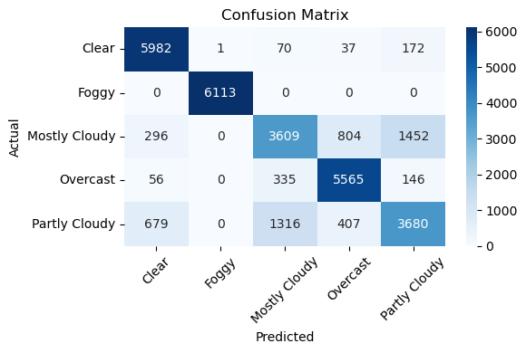

```python
# Compute confusion matrix
cm = confusion_matrix(y_test, y_pred)
# Plot confusion matrix with class labels
plt.figure(figsize=(6, 4))
sns.heatmap(cm, annot=True, fmt='d', cmap='Blues',
            xticklabels=le_summary.classes_,
            yticklabels=le_summary.classes_)
plt.xlabel('Predicted')
plt.ylabel('Actual')
plt.title('Confusion Matrix')
plt.xticks(rotation=45)
plt.yticks(rotation=0)
plt.tight_layout()
plt.show()
```

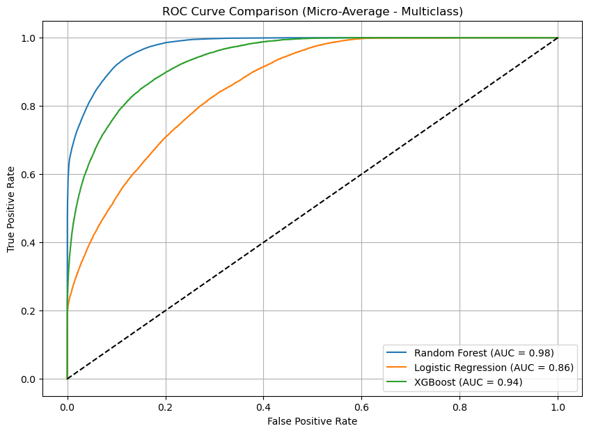

```python
from sklearn.preprocessing import label_binarize

# Binarize the output
classes = np.unique(y_test)
y_test_bin = label_binarize(y_test, classes=classes)

# Get predicted probabilities
rf_probs = best_rf.predict_proba(X_test)
lr_probs = best_lr.predict_proba(X_test)
xgb_probs = best_xgb.predict_proba(X_test)

# Compute micro-average ROC curve and ROC area
fpr_rf, tpr_rf, _ = roc_curve(y_test_bin.ravel(), rf_probs.ravel())
fpr_lr, tpr_lr, _ = roc_curve(y_test_bin.ravel(), lr_probs.ravel())
fpr_xgb, tpr_xgb, _ = roc_curve(y_test_bin.ravel(), xgb_probs.ravel())

auc_rf = auc(fpr_rf, tpr_rf)
auc_lr = auc(fpr_lr, tpr_lr)
auc_xgb = auc(fpr_xgb, tpr_xgb)

# Plotting
plt.figure(figsize=(10, 7))
plt.plot(fpr_rf, tpr_rf, label=f'Random Forest (AUC = {auc_rf:.2f})')
plt.plot(fpr_lr, tpr_lr, label=f'Logistic Regression (AUC = {auc_lr:.2f})')
plt.plot(fpr_xgb, tpr_xgb, label=f'XGBoost (AUC = {auc_xgb:.2f})')

# Diagonal line for random classifier
plt.plot([0, 1], [0, 1], 'k--')

# Aesthetic settings
plt.title('ROC Curve Comparison (Micro-Average - Multiclass)')
plt.xlabel('False Positive Rate')
plt.ylabel('True Positive Rate')
plt.legend(loc='lower right')
plt.grid(True)
plt.show()
```

The **Random Forest** model shows the best performance with an **AUC of 0.98**, closely followed by **XGBoost** at **0.94**, while **Logistic Regression** lags behind at **0.86**. This indicates that **ensemble methods outperform simpler linear models** in capturing complex patterns in your multiclass dataset.